# Pyraxial

### Learning Optics via Python

[Home](https://pyraxial.github.io/blog) | [Github](https://github.com/pyraxial/pyraxial)

# Refraction a single ray at a planar boundary

Auther: Mohammadhossain Modarress -- E-mail: modarres@iasbs.ac.ir

In this code, we simulated a single ray with determined height and angle that refracted at the planar boundary between two media.

First, call `numpy` and `matplotlib` library.

```python
import numpy as np
import matplotlib.pyplot as plt
```

Define a function to calculate The height and angle of a ray traversed a distance in a medium with determined refractive index. In this function:

- `inRay` and `outRay` are two `2*1` arrays that the first elements of them are the height of rays and the second elements are the angles.
- `n` is the refractive index of the medium.
- `d` is the traversed distance in the medium.

```python
def propagation(inRay=np.zeros([2,1]), d=0, n=1):
    rayTransferMatrix = np.array([[1,d/n],[0,1]])
    outRay = rayTransferMatrix.dot(inRay)
    return outRay
```

Define a function to calculate the height and angle of a ray refracted at the planar boundary between two media. In this function:

- `n1` and `n2` are the refractive index of the media.
- `r` is the curvature radius between two media. For planar boundary, `r = inf`.

```python
def refraction(inRay=np.zeros([2,1]), n1=1, n2=1, r=np.inf):
    rayTransferMatrix = np.array([[1,0],[-(n2-n1)/(n2*r),n1/n2]])
    outRay = rayTransferMatrix.dot(inRay)
    return outRay
```

Define the properties of media, boundary and ray.

```python
n_1 = 1 # Refractive index of incidence medium
n_2 = 1.5 # Refractive index of refraction medium
inPlane = .3 # Longitudinal position of the boundry (in meters)

inHeight=0.2 # ray height at the input plane
inAngleDeg = 60 # incident angle in degrees
inAngle=inAngleDeg*(np.pi/180) # incident angle in radian

ray_1 = np.array([[inHeight],[inAngle]])
```

Open a figure and highlight the area of two media on the axes.

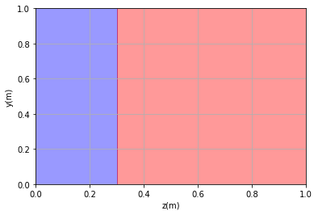

```python
fig = plt.figure()
ax = fig.add_subplot()
plt.axis([0,1,0,1])
plt.xlabel('z(m)')
plt.ylabel('y(m)')
plt.grid()

# First medium
rect1 = plt.Rectangle((0,0),inPlane,1,color='b',alpha=.4)
ax.add_patch(rect1)
# Second medium
rect2 = plt.Rectangle((inPlane,0),1-inPlane,1,color='r',alpha=.4)
ax.add_patch(rect2)

plt.show()
```

Propagate the incident ray, `ray_1`, in the first medium.

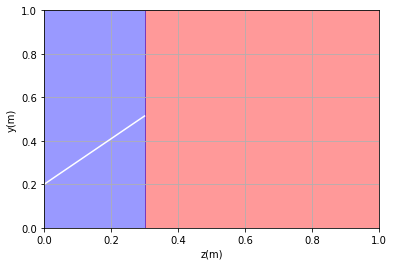

```python
ray_2 = propagation(ray_1,inPlane,n_1)

## Don't repeat this part in the .py file
fig = plt.figure()
ax = fig.add_subplot()
plt.axis([0,1,0,1])
plt.xlabel('z(m)')
plt.ylabel('y(m)')
plt.grid()

rect1 = plt.Rectangle((inPlane,0),1-inPlane,1,color='r',alpha=.4)
ax.add_patch(rect1)
rect2 = plt.Rectangle((0,0),inPlane,1,color='b',alpha=.4)
ax.add_patch(rect2)
##

plt.plot([0,inPlane],[ray_1[0],ray_2[0]],color='w')
plt.show()
```

Calculate the height and angle of the refracted ray at the planar boundary.

```python
ray_3 = refraction(ray_2,n_1,n_2)
```

Propagate the refracted ray, `ray_3`, in the second medium.

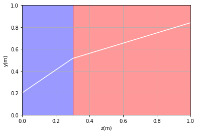

```python
ray_4 = propagation(ray_3,1-inPlane,n_2)


## Don't repeat this part in the .py file
fig = plt.figure()
ax = fig.add_subplot()
plt.axis([0,1,0,1])
plt.xlabel('z(m)')
plt.ylabel('y(m)')
plt.grid()

rect1 = plt.Rectangle((inPlane,0),1-inPlane,1,color='r',alpha=.4)
ax.add_patch(rect1)
rect2 = plt.Rectangle((0,0),inPlane,1,color='b',alpha=.4)
ax.add_patch(rect2)
##

plt.plot([0,inPlane,1],[ray_1[0],ray_2[0],ray_4[0]],color='w')
plt.show()
```

[This code](https://github.com/pyraxial/pyraxial/blob/master/geo_opt/refraction_single_ray.py) is reachable in [our Github repository](https://github.com/pyraxial/pyraxial).